It went well given the situation. I'm not sure I would recommend this format as the only method of bootcamp.

A bit more time experiencing some of the activities that students will participate in.

EL Virtual Bootcamp

Vaishali

May, 19 2020

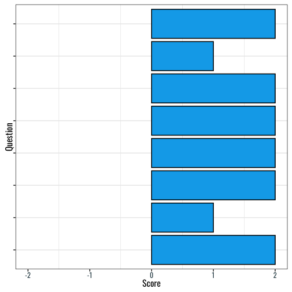

6

I would probably have rated it higher if it was in person, however with the circumstances that would not have been possible, but I think that it would have maybe been more beneficial

it was an intense amount of work, but not sure how to change that and still have the content understanding

EL Virtual Bootcamp

Vaishali

May, 19 2020

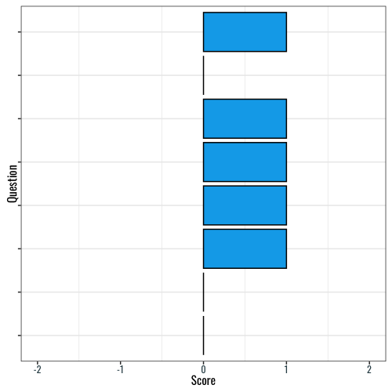

6

it was very repetitive

in person-but no ones fault! I just get distracted

Guidebooks CM-6

Katie

May, 22 2020

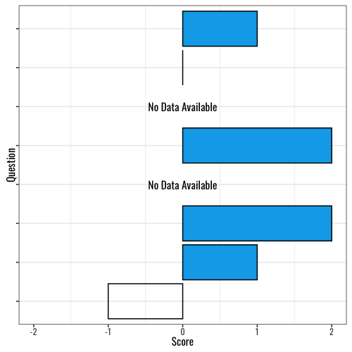

6

Blank

more time with resources

Guidebooks Diverse Learners Vocabulary, Day 1

Holli

Nov, 19 2020

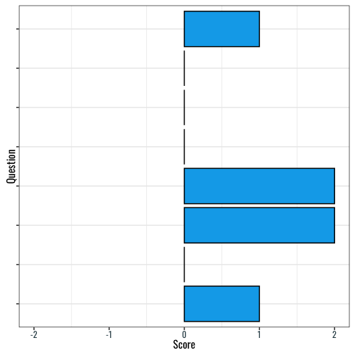

6

It was pretty effective.

Nothing.

Guidebooks Diverse Learners Vocabulary, Day 1

Holli

Nov, 19 2020

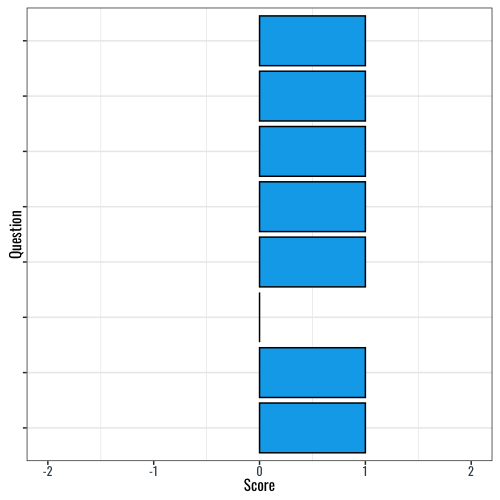

6

Engagement

Shorter session

Guidebooks Diverse Learners Vocabulary, Day 2

Holli

Oct, 30 2020

7

Long for a Saturday

Discussing more how to use these strategies during a time where students were socially distance and can't work/read with a partner.

EL K-5 Text-based Writing, Day 1

Brad

Dec, 05 2020

7

I chose this rating because I believe it would be useful to others.

I wanted to talk more about how to accomplish this work with socially distant protocols .

EL K-5 Text-based Writing, Day 1

Brad

Dec, 05 2020

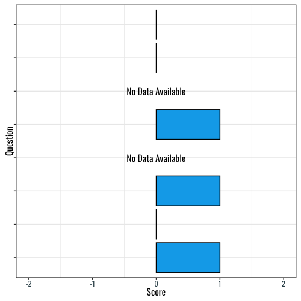

7

The amount of time the lessons required was overwhelming, especially at the close of our school year.

Taking the course via Zoom was a challenge.

EL Virtual Bootcamp

Vaishali

May, 19 2020

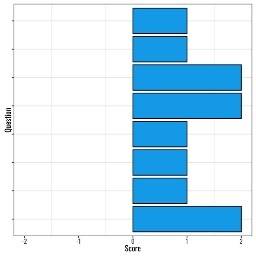

7

It had room to be shorter?? However, I did feel it was worth my time.

The Zoom sessions did not seem that meaningful to me. However, I am not actually going to be teaching this curriculum, so maybe I wasn't as engaged as I should have been.

EL Virtual Bootcamp

Vaishali

May, 19 2020

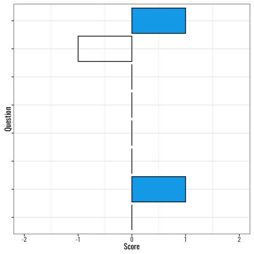

7

It answered some questions, but left me with many. It was a good road to take, but I feel I almost got more from my peers.

Working an example unboxing together then having us do ours on our own. Telling us at the beginning that working with peers, even digitally is best. Being walked through the EL website at the beginning so we could find material a little easier.

EL Virtual Bootcamp

Mandy

May, 20 2020

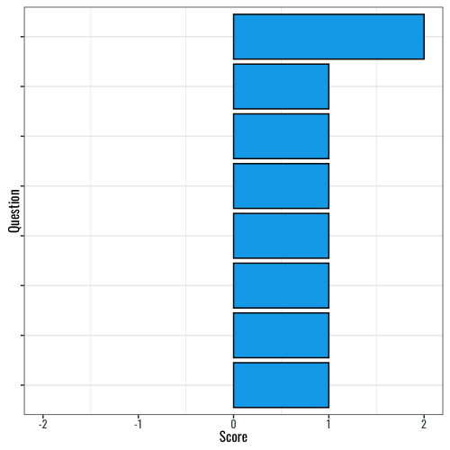

7

I am wanting to know more about the curriculum itself. Diving more into each part of the curriculum and what it teaches.

I was hoping to dive into the curriculum more. Maybe combine a couple sessions to shorten.

EL Virtual Bootcamp

Mandy

May, 19 2020

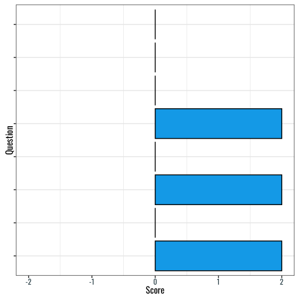

7

all in my district should now have completed this training.

unfortunately, I was called out my admin many times and had to leave, so I missed some content.

Guidebooks CM-6

Meredith

May, 22 2020

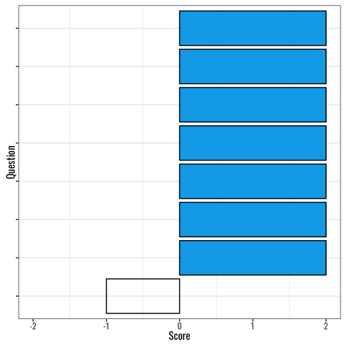

7

Length

Length

Guidebooks CM-6

Meredith

May, 22 2020

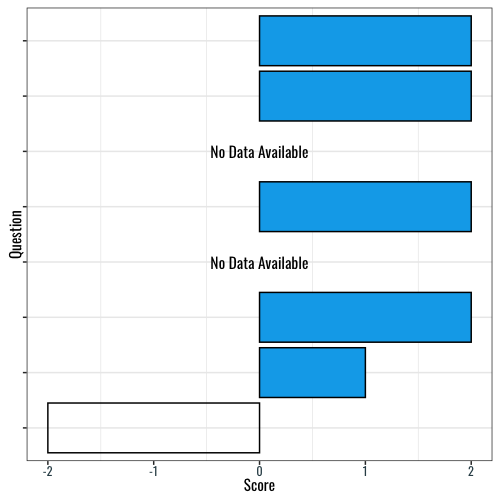

7

Good application of strategies

Less interruptions from school closure procedures

Guidebooks CM-6

Meredith

May, 22 2020

7

The information was good

Nothing

Guidebooks Diverse Learners Fluency, Day 2

Holli

Aug, 28 2020

7

I do feel like there isn't much more said than what is in the notecatcher and I could just simply read it. I would like modelling and examples that are tangible. I feel like I personally still don't have a good grasp on the strategies given.

Modelling the tools and strategies

Guidebooks Diverse Learners Vocabulary, Day 1

Holli

Oct, 30 2020

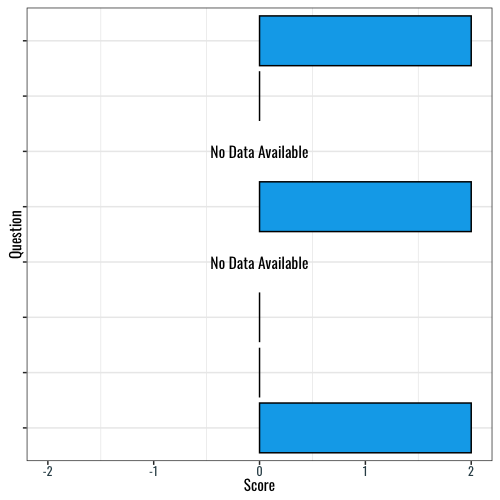

8

EL K-5 Text-based Writing, Day 1

Brad

Dec, 05 2020

8

It was a long session

Learning more remote strategies for writing

EL K-5 Text-based Writing, Day 1

Brad

Dec, 04 2020

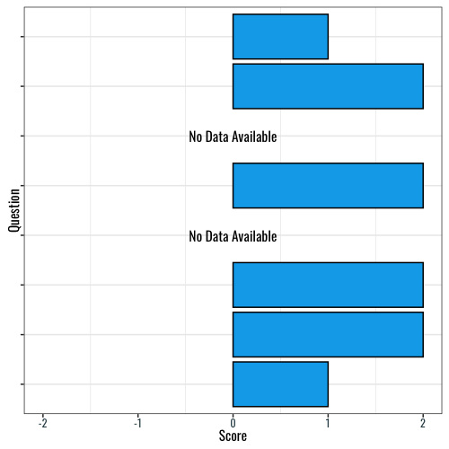

8

It was useful and educational, but I missed out on time to work with other teachers.

Having more time to collaborate with fellow teachers.

EL Virtual Bootcamp

Vaishali

May, 19 2020

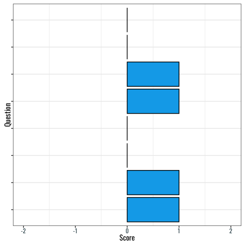

8

I felt like I was well supported throughout the bootcamp.

More time to talk to grade level teachers

EL Virtual Bootcamp

Vaishali

May, 19 2020

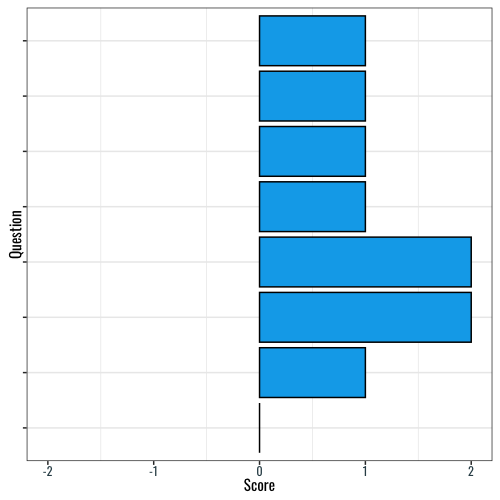

8

I think this curriculum will be good, but still uncertain of what my role looks like.

I would like to have seen a full lesson taught.

EL Virtual Bootcamp

Vaishali

May, 19 2020

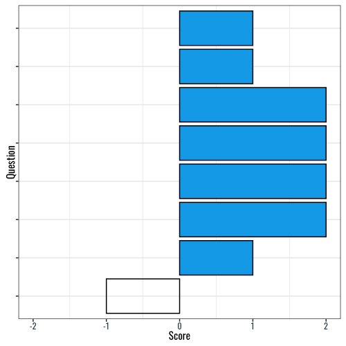

8

I'd still prefer in person, but they did very well.

nothing...

EL Virtual Bootcamp

Vaishali

May, 19 2020

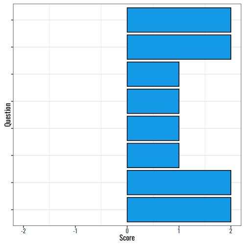

8

I thought it was pretty good but at times I didn't feel we got the answers or things we needed (videos, etc.)

Probably more time to dive in and an in person training but unfortunately we didn't have either of those opportunities

EL Virtual Bootcamp

Vaishali

May, 19 2020

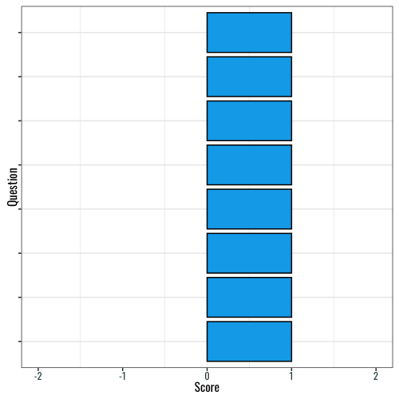

8

It was good, but it wasn't easy.

The training was good, but it the unpacking was almost too much. Honestly, I felt like I should have received college credits for all the work and time we put into it.

EL Virtual Bootcamp

Vaishali

May, 19 2020

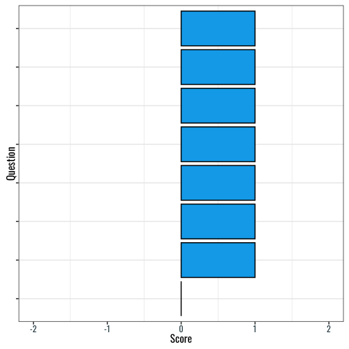

8

It was nice learning about EL and the model, I just wish we could have done some more of the unpacking of a lesson together, to better understand how to do it, as that is a big piece of how we may teach.

Some items we had homework on before we discussed them. I would have liked to have learned about it, and then worked on the assignment after.

EL Virtual Bootcamp

Mandy

May, 19 2020

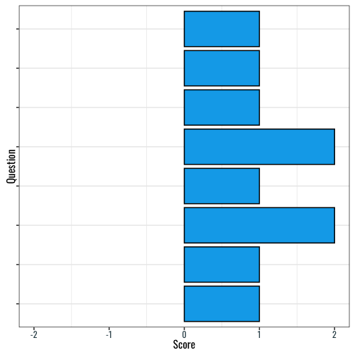

8

I think this was a great use of time and distance learning

the assignments need to be housed in one place when it is a link--get it all to google or all downloaded microsoft. even a google folder broken up in sessions so we can quickly find things. That was exasperating... I have stuff all over now and will have to take the time to organize it all in a google folder.

EL Virtual Bootcamp

Mandy

May, 19 2020

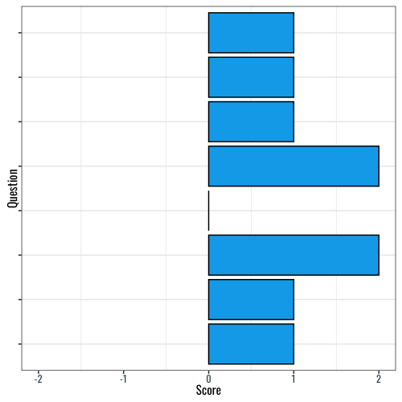

8

.

.

Guidebooks CM-6

Meredith

May, 22 2020

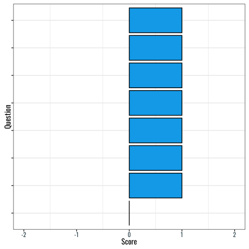

8

It was well done

Being in person

Guidebooks CM-6

Meredith

May, 22 2020

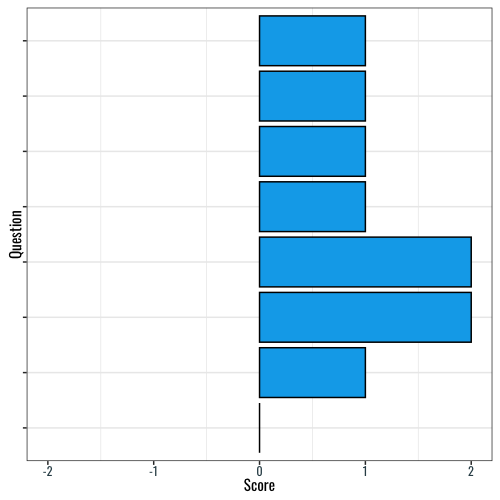

8

While it is excellent, it doesn't work in my circumstances...at least it didn't for me & my behaviorally 'bad' kids!

Having it face-to-face!

Guidebooks CM-6

Katie

May, 22 2020

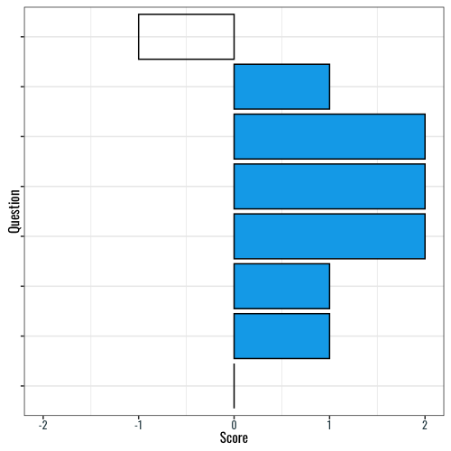

8

Good facilitator

Better scheduling

Guidebooks CM-6

Katie

May, 22 2020

8

The content is useful for English teachers.

More student examples of learning ranging from low. Medium to high.

Guidebooks CM-6

Katie

May, 22 2020

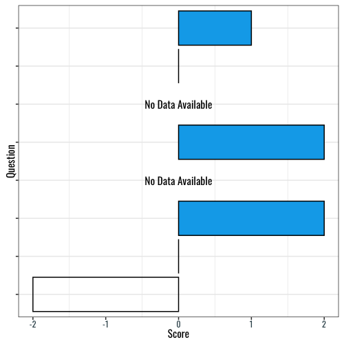

8

it was helpful

being more vocal

Guidebooks CM-6

Katie

May, 22 2020

8

Good facilitator

Better scheduling

Guidebooks CM-6

Katie

May, 22 2020

8

It's not for everyone, but extremely beneficial to me.

I cannot think of anything.

Guidebooks CM-6

Meredith

May, 22 2020

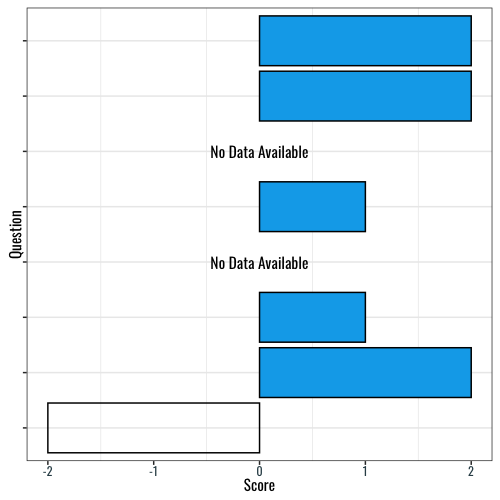

8

Great for new teachers

Nothing

Guidebooks CM-6

Meredith

May, 22 2020

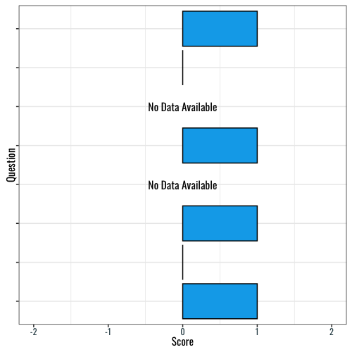

8

It was good information! Just a little long

n/a

Guidebooks Diverse Learners BootCamp, Day 2

Holli

Aug, 28 2020

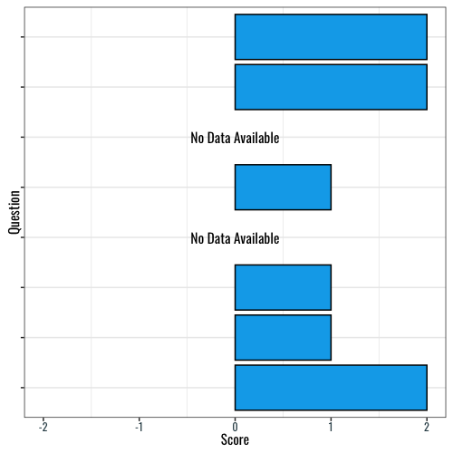

8

its helpful, some things were covered in guidebook training prior to this

n/a

Guidebooks Diverse Learners BootCamp, Day 2

Holli

Aug, 28 2020

8

Some might not need it

Being able to attend all of them

Guidebooks Diverse Learners Fluency, Day 2

Holli

May, 21 2020

8

Some might not need it

Being able to attend all of them

Guidebooks Diverse Learners Fluency, Day 2

Holli

May, 21 2020

8

Some might not need it

Being able to attend all of them

Guidebooks Diverse Learners Fluency, Day 2

Holli

May, 21 2020

8

We have been working on most of these things over the last several years.

Great day

Guidebooks Diverse Learners Fluency, Day 2

Holli

May, 21 2020

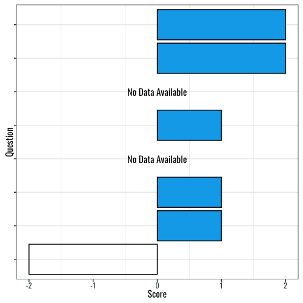

8

N/A

N/A

Guidebooks Diverse Learners Vocabulary, Day 1

Holli

Nov, 19 2020

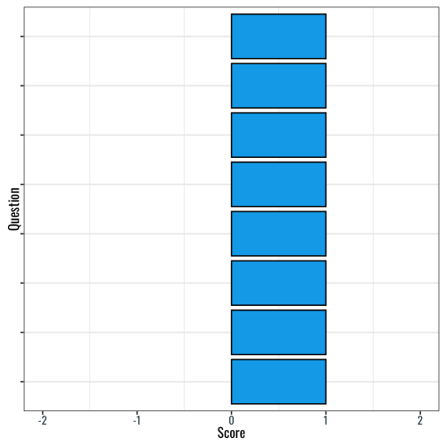

8

It was a good lesson, but didn't have any engagement besides talking. Explanations and strategies given were helpful.

More talking and time to collaborate and plan

Guidebooks Diverse Learners Vocabulary, Day 1

Holli

Nov, 19 2020

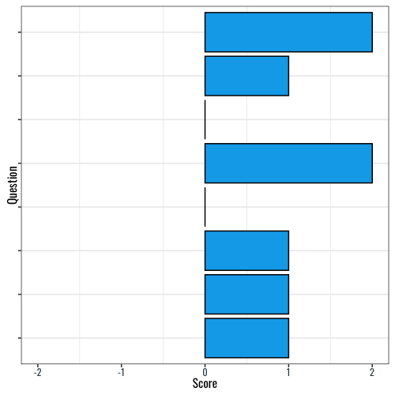

8

Overall, it went well and offered a lot of information to use.

The first session to be more like the second. :)

Guidebooks Diverse Learners Vocabulary, Day 1

Holli

Nov, 19 2020

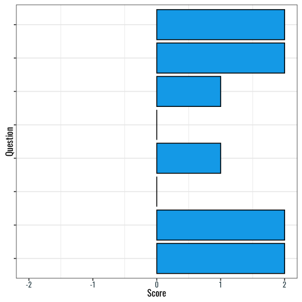

8

It deserves an 8

Quality sound

Guidebooks Diverse Learners Vocabulary, Day 1

Holli

Jun, 17 2020

8

I think the information presented was strong. I did not score a 10 because I would have liked to see more opportunities for engagement and maybe some practice. Additionally, the session was heavy in theory and as practitioners, sometimes, we need actionable solutions without the "guesswork"

More time to engage in discussion- not so heavy on the facilitator speaking and engaging everyone. Reflections & small group tasks would be helpful.

Guidebooks Diverse Learners Vocabulary, Day 1

Holli

Nov, 19 2020

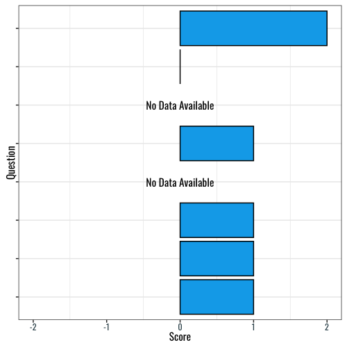

9

I know a ton more than I knew 3 weeks ago.

Not your fault........I will be honest though. Trying to do this while wrapping up the end of the school year was difficult. A lot going on right now. Thanks for everything though.

EL Virtual Bootcamp

Vaishali

May, 19 2020

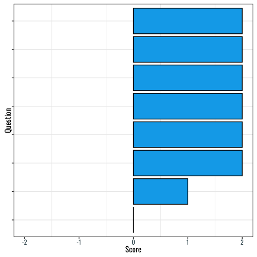

9

Well designed intro course.

More conversation about application in normal setting and also distance learning setting.

EL Virtual Bootcamp

Vaishali

May, 18 2020

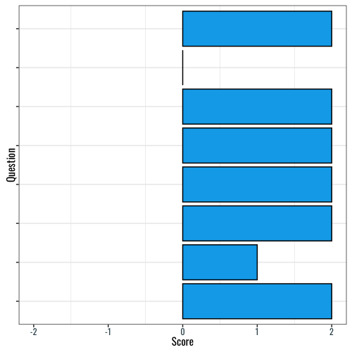

9

I learned a lot! I am more comfortable getting started.

I would have liked to see how an in-person training would have been different, but given the circumstances, this worked well.

EL Virtual Bootcamp

Vaishali

May, 19 2020

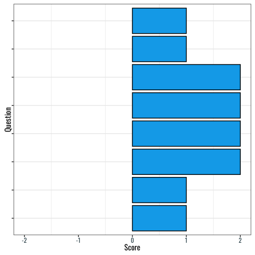

9

The way the training is presented is very systematic making an effective cycle from reading the complex text to responding to it.

I didn't receive an emailed invite with the code to sign in for neither training sessions

Guidebooks CM-6

Meredith

May, 22 2020

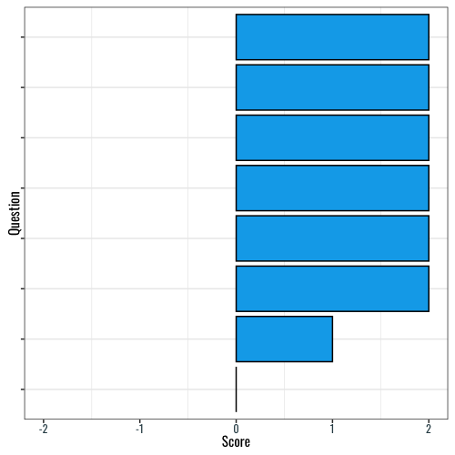

9

It was good information and practice

Na

Guidebooks CM-6

Meredith

May, 22 2020

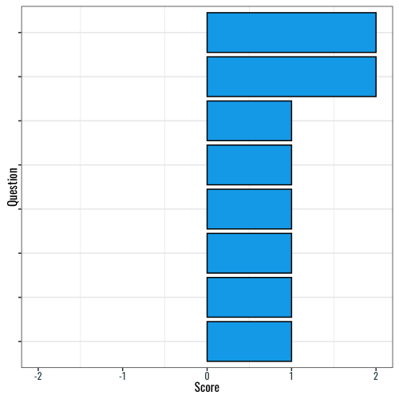

9

I prefer face to face learning but was very good considering the virtual challenges.

Everyone in break out rooms participating

Guidebooks Diverse Learners Fluency, Day 2

Holli

May, 21 2020

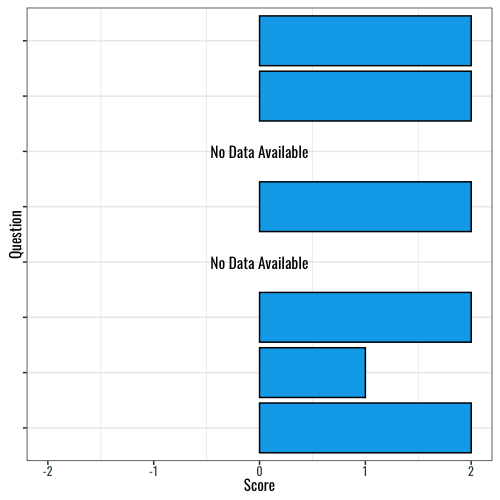

9

Na

Na

Guidebooks Diverse Learners Fluency, Day 2

Holli

May, 21 2020

9

good facilitation

Nebraska IM-PL Fellowship Virtual Series

Tara

Oct, 20 2020

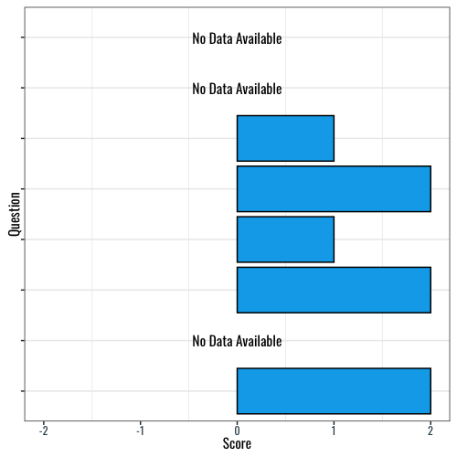

10

Because of the knowledge I'm taking away and my clearer understanding as well as the presenter

Starting this in Mid-August but I just really need to implement what was reveled today.

EL K-5 Text-based Writing, Day 1

Brad

Dec, 05 2020

10

Material and presenter

Nothing

EL K-5 Text-based Writing, Day 1

Brad

Dec, 05 2020

10

I learned quite a bit and feel refreshed and ready for a new year with these new teaching materials and strategies.

Possibly more explanation of where to find things online vs. hard copy? I'm still a little confused on where some items are located...

EL Virtual Bootcamp

Vaishali

May, 19 2020

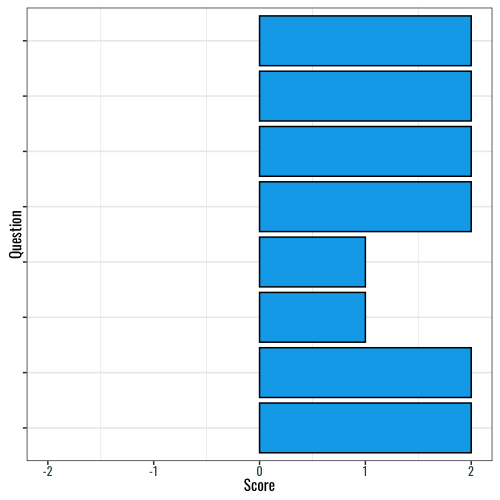

10

The lessons were great.

More detail on helping students write better thesis statements.

Guidebooks CM-6

Meredith

May, 22 2020

10

Very focused

None

Guidebooks CM-6

Meredith

May, 22 2020

10

prefer this online format

nothing

Guidebooks CM-6

Meredith

May, 22 2020

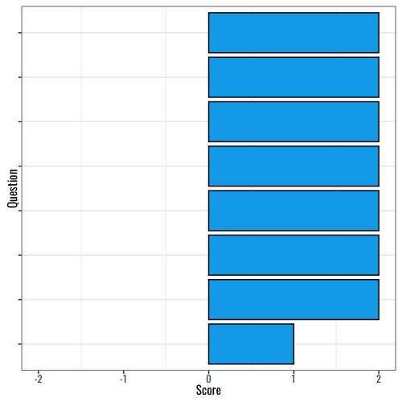

10

I appreciate this opportunity to learn how to help my students better.

No suggestions.

Guidebooks CM-6

Katie

May, 22 2020

10

Enjoyed the meeting.

Nothing

Guidebooks CM-6

Katie

May, 22 2020

10

Guidebooks CM-6

Katie

May, 22 2020

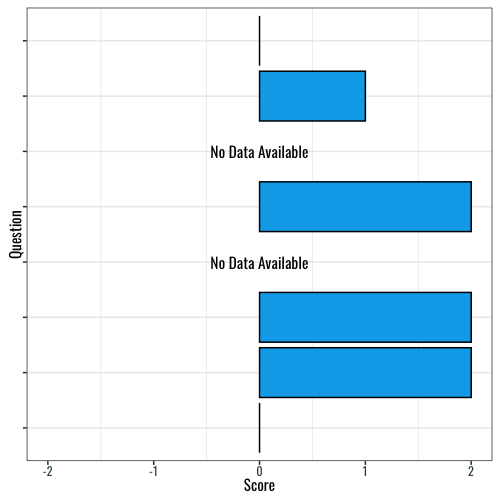

10

great info

timing

Guidebooks CM-6

Katie

May, 22 2020

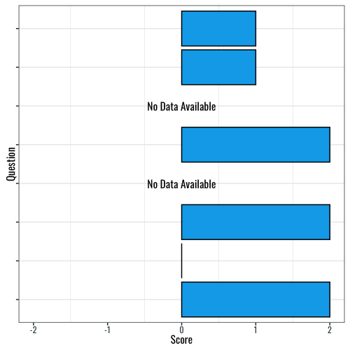

10

Enjoyed the meeting.

Nothing

Guidebooks CM-6

Katie

May, 22 2020

10

It allowed me to learn/ hone skills that I can take back to use immediately.

N/A

Guidebooks CM-6

Katie

May, 22 2020

10

Personal help

Moore time

Guidebooks CM-6

Katie

May, 22 2020

10

Guidebooks CM-6

Katie

May, 22 2020

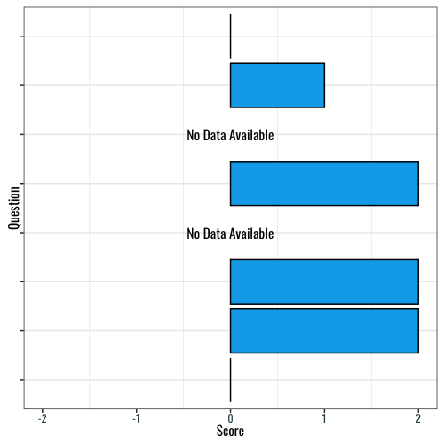

10

Effective presenter

the technology was sketchy - yesterday I was kicked out several times and had to ask permission to reenter - today, the Zoom meeting wouldn't work on my computer; I had to use my cell phone

Guidebooks CM-6

Katie

May, 22 2020

10

It was an informative training.

Nothing really it was good.

Guidebooks CM-6

Katie

May, 22 2020

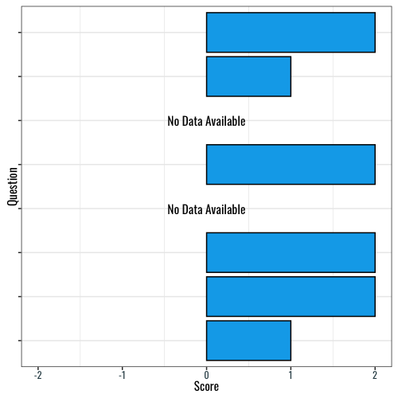

10

thorough

Nothing... maybe earlier in the year

Guidebooks CM-6

Katie

May, 22 2020

10

This professional learning was effective.

N/A

Guidebooks CM-6

Katie

May, 22 2020

10

Enjoyed the meeting.

Nothing

Guidebooks CM-6

Katie

May, 22 2020

10

Based on the ease and flow of presentation by presenter

Nothing

Guidebooks CM-6

Meredith

May, 22 2020

10

Based on the ease and flow of presentation by presenter

Nothing

Guidebooks CM-6

Meredith

May, 22 2020

10

Because it is extremely helpful

Nothing

Guidebooks CM-6

Meredith

May, 22 2020

10

It was great overall

Guidebooks CM-6

Meredith

May, 22 2020

10

It is specific to what's happening in classrooms right now.

Not a thing

Guidebooks CM-6

Meredith

May, 22 2020

10

It can be a helpful process, especially for new or struggling teachers.

Still having a class of students to work with now. Lol

Guidebooks CM-6

Meredith

May, 22 2020

10

Meredith ROCKS!

Nothing

Guidebooks CM-6

Meredith

May, 22 2020

10

Facilitator was helpful

It not being the last day of school with so many interruptions on campus

Guidebooks CM-6

Meredith

May, 22 2020

10

All was good today!

Guidebooks CM-6

Meredith

May, 22 2020

10

Based on the ease and flow of presentation by presenter

Nothing

Guidebooks CM-6

Meredith

May, 22 2020

10

It has helped me understand Learnzillion, which can be quote overwhelming.

Nothing- really liked the brain breaks.

Guidebooks CM-6

Meredith

May, 22 2020

10

great information

nothing

Guidebooks CM-6

Meredith

May, 22 2020

10

It was great overall

Guidebooks CM-6

Meredith

May, 22 2020

10

It was great

Nothing

Guidebooks CM-6

Meredith

May, 22 2020

10

Because it is extremely helpful

Nothing

Guidebooks CM-6

Meredith

May, 22 2020

10

It was great!

It was great!

Guidebooks CM-6

Meredith

May, 22 2020

10

Because I will be suggesting this training to others

This would be a great summer learning activity

Guidebooks Diverse Learners BootCamp, Day 2

Holli

Aug, 28 2020

10

because every teacher needs to group students

being in person rather than virtual

Guidebooks Diverse Learners Fluency, Day 2

Holli

May, 21 2020

10

The program offered a lot of great information

Send information

Guidebooks Diverse Learners Fluency, Day 2

Holli

May, 21 2020

10

Great info was given

Having prior knowledge of the content

Guidebooks Diverse Learners Fluency, Day 2

Holli

May, 21 2020

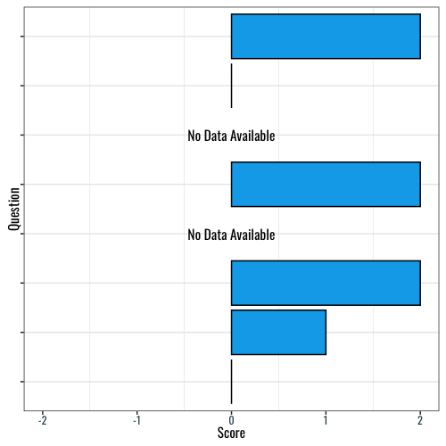

10

All went well and was educational.

Nothing

Guidebooks Diverse Learners Fluency, Day 2

Holli

May, 21 2020

10

Love the content

In person

Guidebooks Diverse Learners Fluency, Day 2

Holli

May, 21 2020

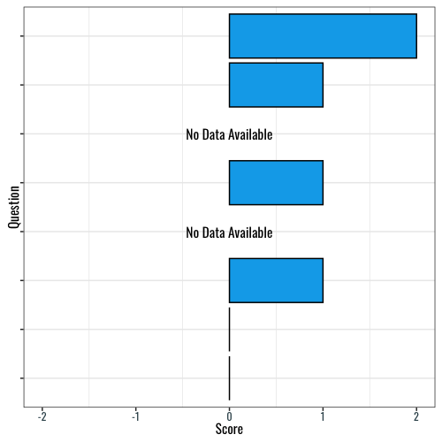

10

Well organized and well presented

Nothing....very well done!

Guidebooks Unit Unpacking

Jalinda

Jun, 10 2020